# compute_metrics

Luna & Sofia

Explanation: We decided to investigate the metric high stream flow because these are important to understand for flooding and drought risk. Additionally, it affects ecosystem and vegetation health, and can help design irrigation solutions that are on a time basis.

The model was ok, with a combined error of 0.65 though the predicted and observed outcomes are highly correlated which is a good sign.

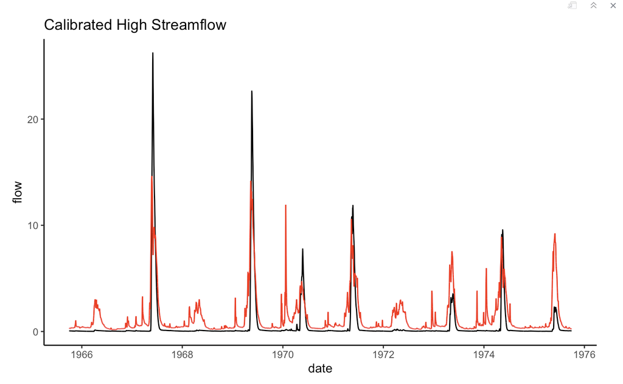

# Comparing model and observed time series output

When evaluating a model - Always plot first

Plotting and what it can tell you

- plot through time
  - look for differences in performance in different periods
  - does model capture seasonlity, temporal trends
- some things to think about that might help make it easier to “see” differences betwee observed time series and mdoelled time series
  - consider appropriate y-axis
  - consider picking a window (subset in x-axis)
- plot x-y (observed vs model)
  - look for bios (error) (using a 1 to 1 line are points always above or below)
  - look for errors associated with particular magnitdues (e.g high or low values)

```r
sager = read.table("../data/sager.txt", header=T)
head(sager)
```

```
##       model       obs month day year   wy wyd
## 1 0.4238063 0.3358678    10   1 1965 1966   1
## 2 0.4133587 0.3208737    10   2 1965 1966   2
## 3 0.4032640 0.3058796    10   3 1965 1966   3
## 4 0.3935287 0.2968832    10   4 1965 1966   4
## 5 0.3841480 0.2968832    10   5 1965 1966   5
## 6 0.3751000 0.2968832    10   6 1965 1966   6
```

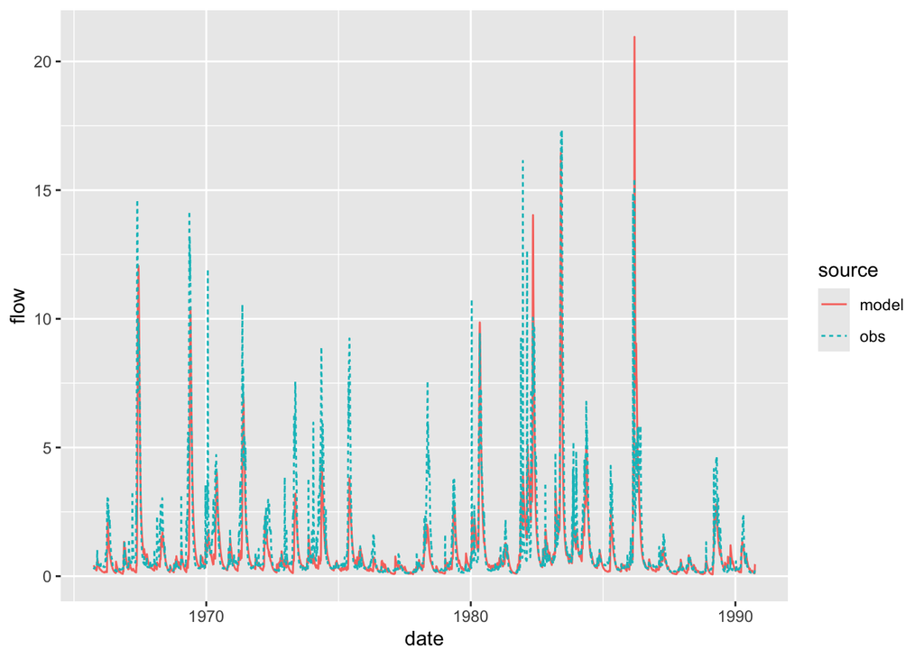

```r
# add date
sager = sager %>% mutate(date = paste(day,month,year, sep="/"))
sager$date = as.Date(sager$date,"%d/%m/%Y")

# plot
sagerl = sager %>% pivot_longer(cols=c("model","obs"), names_to="source",
                                  values_to="flow")

# basic plot
ggplot(sagerl, aes(date, flow, col=source, linetype=source))+geom_line()
```

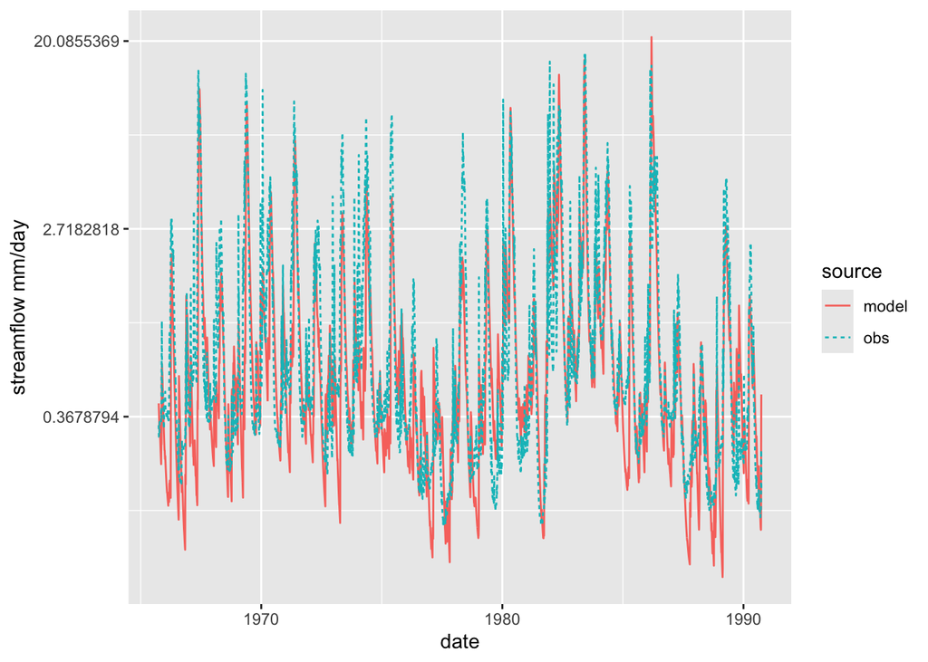

```r
# change axis to get a closer look at performance at low values
# when you have high dynamic range (lots of large and small values), taking log can help
# with visualization
ggplot(sagerl, aes(date, flow, col=source, linetype=source))+geom_line()+scale_y_continuous(trans="log")+labs(y="streamflow mm/day")
```

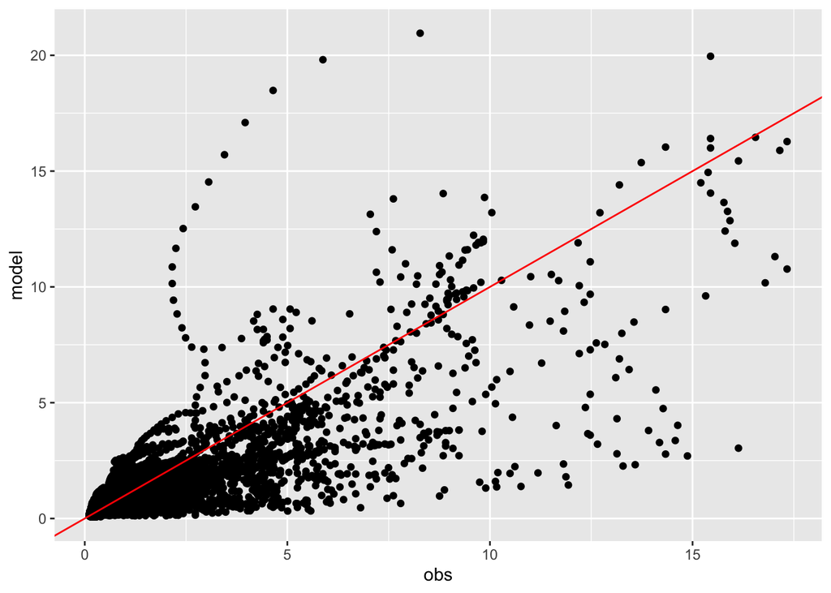

```r
# look at it another way
ggplot(sager, aes(obs, model))+geom_point()+geom_abline(intercept=0, slope=1, col="red")
```

# Measure Performance using different metrics

Once you’ve plotted, consider some metrics that summarize performance

Think about what part of the time-series is of interest

- long term means (bims)
- year to year variablity
- peak or minimum events

Create performance metrics that are relevant to the model application

Lets start though with some simple metrics

```r
source("../../R/nse.R")

source("../../R/relerr.R")


source("../../R/cper.R")

nse
```

```
## function (m, o)
## {
##     err = m - o
##     meanobs = mean(o)
##     mse = sum(err * err)
##     ovar = sum((o - meanobs) * (o - meanobs))
##     nse = 1 - mse/ovar
##     return(nse)
## }
```

```r
relerr
```

```
## function (m, o)
## {
##     err = m - o
##     meanobs = mean(o)
##     meanerr = mean(err)
##     res = meanerr/meanobs
##     return(res)
## }
```

```r
cper
```

```
## function (m, o, weight.nse = 0.5, weight.relerr = 0.5)
## {
##     nse = nse(m, o)
##     mnse = max(nse, 0)
##     rel.err = relerr(m, o)
##     merr = 1 - min(1, abs(rel.err)/max(abs(rel.err)))
##     combined = weight.nse * mnse + weight.relerr * merr
##     return(combined)
## }
```

```r
nse(m=sager$model, o=sager$obs)
```

```
## [1] 0.6253416
```

```r
relerr(m=sager$model, o=sager$obs)*100
```

```
## [1] -18.9577
```

```r
cper(m=sager$model, o=sager$obs, weight.nse=0.8)
```

```
## [1] 0.5002733
```

# Scale and subsetting

Performance also depends on the ‘what’ you are evaluating

- time steps (annual, daily, monthly)
- selection of particular periods of time

# try another metric

- high streamflow

```r
# use sagerl
sagerl
```

```
## # A tibble: 18,260 × 8
##    month   day  year    wy   wyd date       source  flow
##    <int> <int> <int> <int> <int> <date>     <chr>  <dbl>
##  1    10     1  1965  1966     1 1965-10-01 model  0.424
##  2    10     1  1965  1966     1 1965-10-01 obs    0.336
##  3    10     2  1965  1966     2 1965-10-02 model  0.413
##  4    10     2  1965  1966     2 1965-10-02 obs    0.321
##  5    10     3  1965  1966     3 1965-10-03 model  0.403
##  6    10     3  1965  1966     3 1965-10-03 obs    0.306
##  7    10     4  1965  1966     4 1965-10-04 model  0.394
##  8    10     4  1965  1966     4 1965-10-04 obs    0.297
##  9    10     5  1965  1966     5 1965-10-05 model  0.384
## 10    10     5  1965  1966     5 1965-10-05 obs    0.297
## # ℹ 18,250 more rows
```

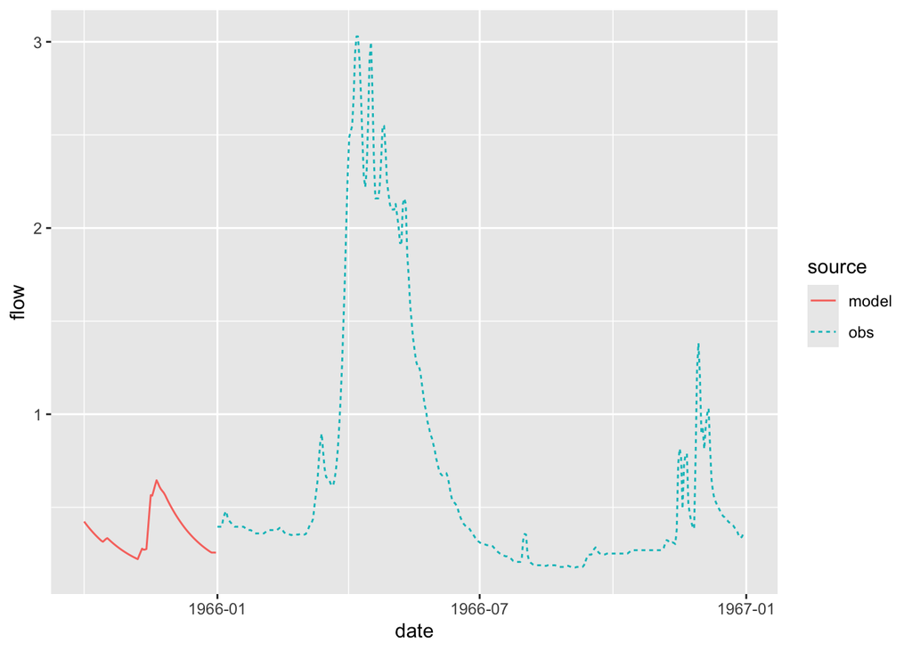

```r
sagerl = sager %>% pivot_longer(cols=c("model","obs"), names_to="source",
                                  values_to="flow")

subset <- sagerl %>%
  filter(year == 1965:1966)

# basic plot looking at yearly flow
ggplot(subset, aes(date, flow, col=source, linetype=source)) +
  geom_line()
```

```r
# turn your evaluation metric into a function
source("../../R/compute_highflowmetrics.R")
compute_highflowmetrics
```

```
## function (m, o, month, day, year, wy, high_flow_months = 3)
## {
##     flow = cbind.data.frame(m, o, month, day, year, wy)
##     tmp = flow %>% group_by(wy) %>% summarize(maxo = max(o),
##         maxm = max(m))
##     annual_max_err = mean(tmp$maxm - tmp$maxo)
##     annual_max_cor = cor(tmp$maxm, tmp$maxo)
##     tmp = flow %>% group_by(month, year) %>% summarize(model = sum(m),
##         obs = sum(o))
##     high = subset(tmp, month %in% high_flow_months)
##     high_month_err = mean(high$model - high$obs)
##     high_month_cor = cor(high$model, high$obs)
##     return(list(annual_max_err = annual_max_err, annual_max_cor = annual_max_cor,
##         high_month_err = high_month_err, high_month_cor = high_month_cor))
## }
```

```r
compute_highflowmetrics(m=sager$model,o=sager$obs, month=sager$month, day=sager$day, year=sager$year, wy=sager$wy)
```

```
## $annual_max_err
## [1] -1.930857
##
## $annual_max_cor
## [1] 0.8897863
##
## $high_month_err
## [1] 2.726873
##
## $high_month_cor
## [1] 0.9047016
```

```r
# use different low flow months
compute_highflowmetrics(m=sager$model,o=sager$obs, month=sager$month, day=sager$day, year=sager$year, wy=sager$wy,
                        high_flow_months = c(1:3)) # select based on time series
```

```
## $annual_max_err
## [1] -1.930857
##
## $annual_max_cor
## [1] 0.8897863
##
## $high_month_err
## [1] -2.514821
##
## $high_month_cor
## [1] 0.773148
```

# Create a combined metric

Sometime you want to summarize everything in one number

Especially if you want to rank different models or create indices like Sobol Sensitivity Indices

```r
perf = compute_highflowmetrics(m=sager$model,o=sager$obs, month=sager$month, day=sager$day, year=sager$year, wy=sager$wy, high_flow_months = c(1:3))

perf = as.data.frame((perf))
# remember you want error to be low but correlation to be high
# so we need to transform in some way

# normalize by max error = if error is greater than this we don't care
# many ideas -  maybe 50% of mean daily summer observed low flow
tmp = sager %>% subset(month %in% c(7:9))
errmax = mean(tmp$obs)*0.5

perf = perf %>% mutate(annual_max_err_trans = max(0,(1-abs(annual_max_err/errmax) )))

# for monthly we can do a simpler thing to find maximum allowable errror
tmp = sager %>% subset(month %in% c(7:9)) %>% group_by(wy, month) %>% summarize(obs=sum(obs))

errmax = mean(tmp$obs)*0.5

perf = perf %>% mutate(high_month_err_trans = max(0,(1-abs(high_month_err/errmax) )))

# now we have 4 measures that we can combine together

perf = perf %>%
  mutate(combined = (annual_max_cor + annual_max_err_trans + high_month_err_trans + high_month_cor)/4)

perf
```

```
##   annual_max_err annual_max_cor high_month_err high_month_cor
## 1      -1.930857      0.8897863      -2.514821       0.773148
##   annual_max_err_trans high_month_err_trans  combined
## 1                    0            0.6363269 0.5748153
```

```r
# or weight differently - we know that minimum flows are hard to get to weight those differently

perf = perf %>%
  mutate(combined2 = 0.1*annual_max_cor + 0.1*annual_max_err_trans + 0.4*high_month_err_trans+ 0.4*high_month_cor)

perf
```

```
##   annual_max_err annual_max_cor high_month_err high_month_cor
## 1      -1.930857      0.8897863      -2.514821       0.773148
##   annual_max_err_trans high_month_err_trans  combined combined2
## 1                    0            0.6363269 0.5748153 0.6527686
```

```r
# easier to put all this in a function
```

# Calibration

Calibration is picking parameter sets based on performance evaluation

Apply metrics over multiple outputs (generated by running across many parameters sets)

Ideally we’d generate these parameter “smartly” - LHS or Sobol sampling

Example - a dataset where each column is a different model run for Sagehen Creek (using different parameters)

don’t worry about what the parameters are for now

File Name * sagerm.txt

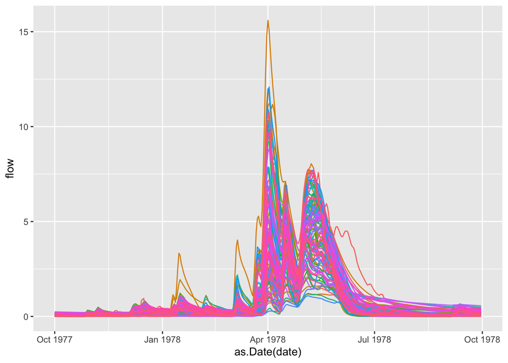

```r
# multiple results - lets say we've run the model for multiple years, each column
# is streamflow for a different parameter set
msage = read.table("../data/sagerm.txt", header=T)

# lets say we know the start date from our earlier output
msage$date = sager$date
msage$month = sager$month
msage$year = sager$year
msage$day = sager$day
msage$wy = sager$wy

# and we still have observed data from above
msage = left_join(msage, sager[,c("obs","date")], by=c("date"))

# subset for split sample calibration
short_msage = subset(msage, wy < 1975)


# how can we plot all results - lets plot water year 1970 otherwise its hard to see
msagel = msage %>%
  pivot_longer(cols=!c(date, month, year, day,wy), names_to="run", values_to="flow")


p1=ggplot(subset(msagel, wy == 1978), # subset for only this year
          aes(as.Date(date), flow, col=run)) +
  geom_line() +
  theme(legend.position = "none")
p1
```

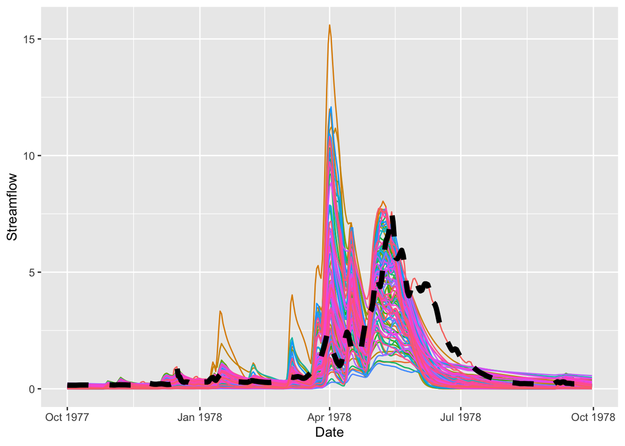

```r
# lets add observed streamflow
p1 + geom_line(data=subset(sager, wy == 1978), aes(as.Date(date), obs),
               size=2, col="black", linetype=2) +
  labs(y="Streamflow", x="Date")
```

```r
# subset for split sample calibration
short_msage = subset(msage, wy < 1976)

# compute performance measures for output from all parameters
res <- short_msage %>%
  select(!c("date","month","year","day","wy","obs")) %>%
  map_dbl(nse, short_msage$obs)


head(res)
```

```
##      V99.1     V100.1       V101       V102       V103       V104
## -0.4018755  0.5683704  0.3593249  0.3106171  0.3987668  0.4292975
```

```r
# another example using our low flow statistics
# use apply to compute for all the data
# using the updated high flow metrics routing that also computed combined metrics

source("../../R/compute_highflowmetrics_all.R")
res = short_msage %>% select(-date, -month, -day, -year, -wy, -obs ) %>%
  map_df(compute_highflowmetrics_all, o=short_msage$obs, month=short_msage$month,
        day=short_msage$day, year=short_msage$year, wy=short_msage$wy)


# interesting to look at range of metrics - could use this to decide on
# acceptable values
summary(res)
```

```
##  annual_max_err   annual_max_cor   high_month_err    high_month_cor
##  Min.   :-6.605   Min.   :0.7771   Min.   :-29.296   Min.   :0.3649
##  1st Qu.: 1.160   1st Qu.:0.8686   1st Qu.:-21.976   1st Qu.:0.6563
##  Median : 3.480   Median :0.8911   Median :-17.680   Median :0.6997
##  Mean   : 3.657   Mean   :0.8860   Mean   :-16.323   Mean   :0.6950
##  3rd Qu.: 6.610   3rd Qu.:0.9133   3rd Qu.: -9.654   3rd Qu.:0.7406
##  Max.   :12.749   Max.   :0.9311   Max.   :  6.543   Max.   :0.8112
##     combined
##  Min.   :0.3756
##  1st Qu.:0.4368
##  Median :0.5085
##  Mean   :0.5030
##  3rd Qu.:0.5609
##  Max.   :0.6457
```

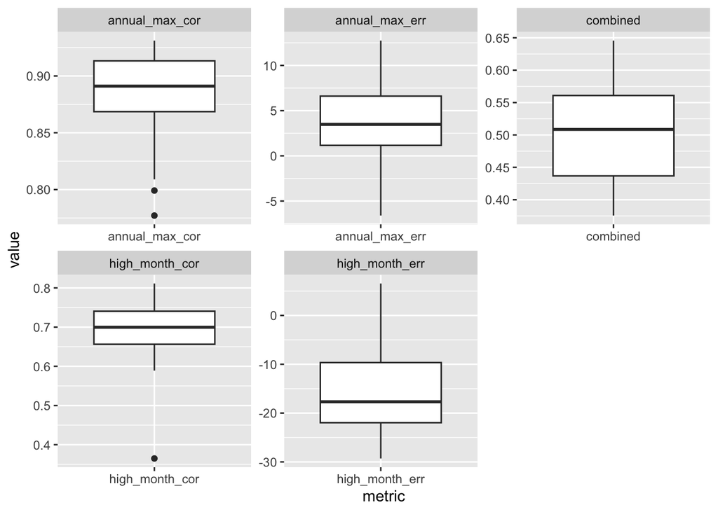

```r
# graph range of performance measures
resl = res %>%
  pivot_longer(cols=everything(), names_to="metric", values_to="value")
ggplot(resl, aes(metric, value))+
  geom_boxplot()+
  facet_wrap(~metric, scales="free")
```

```r
# try this
# assign an identifier to each row, use the same identify for columns of original streamflow data
# we can then use that to pick data
res$run = seq(from=1,to=nrow(res))

colnames(msage)=c(res$run, "date", "month", "year","day","wy", "obs")

colnames(msage)
```

```
##   [1] "1"     "2"     "3"     "4"     "5"     "6"     "7"     "8"     "9"
##  [10] "10"    "11"    "12"    "13"    "14"    "15"    "16"    "17"    "18"
##  [19] "19"    "20"    "21"    "22"    "23"    "24"    "25"    "26"    "27"
##  [28] "28"    "29"    "30"    "31"    "32"    "33"    "34"    "35"    "36"
##  [37] "37"    "38"    "39"    "40"    "41"    "42"    "43"    "44"    "45"
##  [46] "46"    "47"    "48"    "49"    "50"    "51"    "52"    "53"    "54"
##  [55] "55"    "56"    "57"    "58"    "59"    "60"    "61"    "62"    "63"
##  [64] "64"    "65"    "66"    "67"    "68"    "69"    "70"    "71"    "72"
##  [73] "73"    "74"    "75"    "76"    "77"    "78"    "79"    "80"    "81"
##  [82] "82"    "83"    "84"    "85"    "86"    "87"    "88"    "89"    "90"
##  [91] "91"    "92"    "93"    "94"    "95"    "96"    "97"    "98"    "99"
## [100] "100"   "101"   "date"  "month" "year"  "day"   "wy"    "obs"
```

```r
# best one
best = res[which.max(res$combined),]
worst = res[which.min(res$combined),]

best
```

```
## # A tibble: 1 × 6
##   annual_max_err annual_max_cor high_month_err high_month_cor combined   run
##            <dbl>          <dbl>          <dbl>          <dbl>    <dbl> <int>
## 1         -0.159          0.880          -28.7          0.740    0.646    43
```

```r
worst
```

```
## # A tibble: 1 × 6
##   annual_max_err annual_max_cor high_month_err high_month_cor combined   run
##            <dbl>          <dbl>          <dbl>          <dbl>    <dbl> <int>
## 1          -5.05          0.809          -23.4          0.693    0.376    95
```

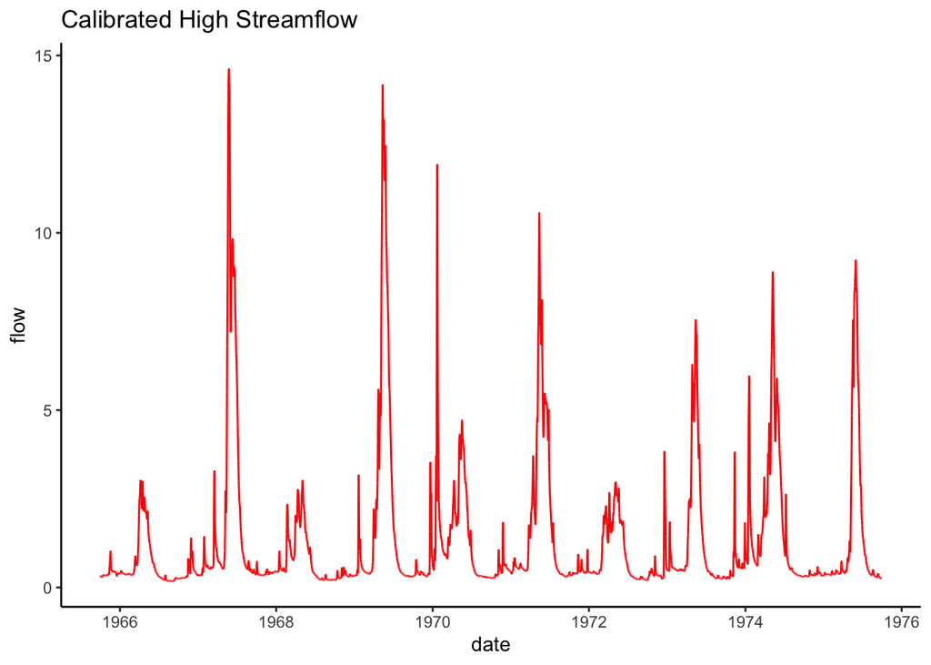

```r
msagel <- short_msage %>%
  pivot_longer(cols=!c(date, month, year, day, wy, obs), names_to="run", values_to="flow")

# post calibration based on BEST run
ggplot(subset(msagel, run == best$run),
       aes(date, flow)) +
  geom_line(color = "black") +
  # plotting based on observations
  geom_line(data = msagel, aes(date, obs), col="red") +
  theme_classic() +
  labs(title = "Calibrated High Streamflow")
```

Compare runs

```r
compruns = msagel %>% select(best$sim, worst$sim, date, obs, month, day, year, wy)
 compruns = subset(compruns, wy > 1970)
 compruns_mwy = compruns %>% select(-c(day,date, year)) %>% group_by(month, wy) %>%
        summarize(across(everything(), mean))
```